# Tugas Individu 3

Raziqizzan Putrandi - G1401211040

```r
library(dLagM)
library(dynlm)
library(MLmetrics)
library(lmtest)
library(readxl)
```

# Input data

```r
data3 <- read_excel("C:\\Users\\User\\Documents\\raziq\\semseter 5\\MPDW\\praktikum\\Prak MPDW\\pertemuan 3\\data tugas 3.xlsx", sheet = 1)
data3
```

| open | High | low | close | volume | close(t-1) | open(t-1) | high(t-1) | low(t-1) | volume(t-1) |
| --- | --- | --- | --- | --- | --- | --- | --- | --- | --- |
| 11.12 | 11.55 | 11.12 | 11.12 | 4864322 | NA | NA | NA | NA | NA |
| 10.76 | 11.28 | 10.76 | 10.76 | 5520210 | 11.12 | 11.12 | 11.55 | 11.12 | 4864322 |
| 10.92 | 10.98 | 10.73 | 10.92 | 7038886 | 10.76 | 10.76 | 11.28 | 10.76 | 5520210 |
| 11.42 | 11.42 | 10.86 | 11.42 | 7282602 | 10.92 | 10.92 | 10.98 | 10.73 | 7038886 |
| 11.44 | 11.74 | 11.26 | 11.44 | 7075356 | 11.42 | 11.42 | 11.42 | 10.86 | 7282602 |
| 11.45 | 11.45 | 11.20 | 11.45 | 5626819 | 11.44 | 11.44 | 11.74 | 11.26 | 7075356 |
| 11.32 | 11.62 | 11.32 | 11.32 | 5579050 | 11.45 | 11.45 | 11.45 | 11.20 | 5626819 |
| 11.02 | 11.59 | 11.02 | 11.02 | 9052957 | 11.32 | 11.32 | 11.62 | 11.32 | 5579050 |
| 11.11 | 11.44 | 11.06 | 11.11 | 4987451 | 11.02 | 11.02 | 11.59 | 11.02 | 9052957 |
| 11.36 | 11.52 | 11.05 | 11.36 | 5274492 | 11.11 | 11.11 | 11.44 | 11.06 | 4987451 |

[output cut: 189 more lines]

# Pembagian data dan data time series

```r
train3 <- data3[1:159,]
test3 <- data3[160:199,]

data3.ts <- ts(data3)
train3.ts <- ts(train3)
test3.ts <- ts(test3)
```

# 1. Model Koyck

```r
model3.koyck <- koyckDlm(x = train3$High, y = train3$low, intercept = TRUE)
summary(model3.koyck)
```

```
##
## Call:
## "Y ~ (Intercept) + Y.1 + X.t"
##
## Residuals:
##      Min       1Q   Median       3Q      Max
## -0.50508 -0.07288  0.02254  0.09341  0.23604
##
## Coefficients:
##             Estimate Std. Error t value Pr(>|t|)
## (Intercept)  -0.7280     0.3210  -2.268  0.02472 *
## Y.1           0.3576     0.1110   3.221  0.00156 **
## X.t           0.6793     0.1263   5.377 2.73e-07 ***
## ---
## Signif. codes:  0 '***' 0.001 '**' 0.01 '*' 0.05 '.' 0.1 ' ' 1
##
## Residual standard error: 0.1368 on 155 degrees of freedom
## Multiple R-Squared: 0.9661,  Adjusted R-squared: 0.9657
## Wald test:  2109 on 2 and 155 DF,  p-value: < 2.2e-16
##
## Diagnostic tests:
## NULL
##
##                              alpha     beta       phi
## Geometric coefficients:  -1.133224 0.679273 0.3575678
```

```r
AIC(model3.koyck)
```

```
## [1] -175.3184
```

```r
BIC(model3.koyck)
```

```
## [1] -163.068
```

Dari hasil tersebut, didapat bahwa intercept , peubah $x_t$ dan $y_{t-1}$ memiliki nilai $P-Value<0.05$. Hal ini menunjukkan bahwa intercept, peubah $x_t$ dan $y_{t-1}$ berpengaruh signifikan terhadap $y_t$. Adapun model keseluruhannya adalah sebagai berikut
$$\hat{Y_t}= -0.7280+0.6793X_t+ 0.3576 Y_{t-1}$$

### Peramalan dan akurasi model koyck

```r
# peramalan 40 periode kedepan
frc.koyck <- forecast(model = model3.koyck, x=test3$High, h=40)
frc.koyck
```

```
## $forecasts
##  [1] 14.06483 14.05547 14.04533 14.04171 14.03362 13.97638 13.91516 13.85251
##  [9] 13.83691 13.79057 13.82834 13.90978 13.92531 13.89690 13.87995 13.96898
## [17] 13.94648 13.89088 13.87100 13.86390 13.87494 13.86530 13.84148 13.90089
## [25] 13.86779 13.93747 13.94200 13.97079 13.97430 13.98234 13.99880 13.97073
## [33] 13.99465 13.94207 14.08630 14.30089 14.44555 14.48369 14.60601 14.75164
##
## $call
## forecast.koyckDlm(model = model3.koyck, x = test3$High, h = 40)
##
## attr(,"class")
## [1] "forecast.koyckDlm" "dLagM"
```

```r
#akurasi data test
mape3.koyck <- MAPE(frc.koyck$forecasts, test3$low)
mape3.koyck
```

```
## [1] 0.008237954
```

```r
#akurasi data training
GoF(model3.koyck)
```

|  | n | MAE | MPE | MAPE | sMAPE | MASE | MSE | MRAE | GMRAE |
| --- | --- | --- | --- | --- | --- | --- | --- | --- | --- |
| model3.koyck | 158 | 0.1035927 | -0.0001206472 | 0.008146291 | 0.008129521 | 0.66411 | 0.0183501 | 68052582 | 1.489726 |

# 2. Model Distributed Lag

### dengan lag 3

```r
model3.dl <- dlm(x = train3$High, y = train3$low, q=3)
summary(model3.dl)
```

```
##
## Call:
## lm(formula = model.formula, data = design)
##
## Residuals:
##      Min       1Q   Median       3Q      Max
## -0.58383 -0.07415  0.02740  0.09849  0.22615
##
## Coefficients:
##             Estimate Std. Error t value Pr(>|t|)
## (Intercept) -1.28467    0.24148  -5.320 3.68e-07 ***
## x.t          0.80317    0.05604  14.333  < 2e-16 ***
## x.1          0.20644    0.07166   2.881  0.00455 **
## x.2          0.03402    0.07164   0.475  0.63551
## x.3          0.02478    0.05405   0.459  0.64721
## ---
## Signif. codes:  0 '***' 0.001 '**' 0.01 '*' 0.05 '.' 0.1 ' ' 1
##
## Residual standard error: 0.1454 on 151 degrees of freedom
## Multiple R-squared:  0.9584, Adjusted R-squared:  0.9573
## F-statistic: 868.9 on 4 and 151 DF,  p-value: < 2.2e-16
##
## AIC and BIC values for the model:
##         AIC       BIC
## 1 -151.9338 -133.6346
```

```r
AIC(model3.dl)
```

```
## [1] -151.9338
```

```r
BIC(model3.dl)
```

```
## [1] -133.6346
```

Dari hasil diatas, didapat bahwa $P-value$ dari intercept, $x_{t}$ dan $x_{t-1}<0.05$. Hal ini menunjukkan bahwa intercept, $x_{t}$ dan $x_{t-1}$ berpengaruh signifikan terhadap $y_t$. Adapun model keseluruhan yang terbentuk adalah sebagai berikut

$$\hat{Y_t}=-1.28467+
0.80317X_t+0.20644X_{t-1}+0.03402X_{t-2}+0.02478X_{t-3}$$

### Peramalan dan akurasi model Distributed Lag (lag=3)

```r
# peramalan 40 periode kedepan
frc.dl <- forecast(model = model3.dl, x=test3$High, h=40)
frc.dl
```

```
## $forecasts
##  [1] 14.06214 14.05822 14.05071 14.04750 14.03937 13.97281 13.90776 13.84422
##  [9] 13.83584 13.78618 13.83690 13.93194 13.93776 13.89885 13.88230 13.99048
## [17] 13.95355 13.88533 13.87163 13.86726 13.88159 13.86966 13.84211 13.91605
## [25] 13.87092 13.95345 13.95388 13.98192 13.98410 13.99068 14.00946 13.97352
## [33] 14.00429 13.94112 14.11576 14.35625 14.49204 14.51074 14.64447 14.79977
##
## $call
## forecast.dlm(model = model3.dl, x = test3$High, h = 40)
##
## attr(,"class")
## [1] "forecast.dlm" "dLagM"
```

```r
#akurasi data test
mape3.dl <- MAPE(frc.dl$forecasts, test3$low)
mape3.dl
```

```
## [1] 0.007500818
```

```r
#akurasi data training
GoF(model3.dl)
```

|  | n | MAE | MPE | MAPE | sMAPE | MASE | MSE | MRAE | GMRAE |
| --- | --- | --- | --- | --- | --- | --- | --- | --- | --- |
| model3.dl | 156 | 0.108863 | -0.0001185989 | 0.008536209 | 0.008515689 | 0.6935376 | 0.02047124 | 80473213 | 1.541626 |

### dengan lag Optimmum

```r
# cari lag optimum
finiteDLMauto(formula =low ~ High,
              data = data.frame(train3), q.min = 1, q.max = 6,
              model.type = "dlm", error.type = "AIC", trace = FALSE)
```

|  | q - k | MASE | AIC | BIC | GMRAE | MBRAE | R.Adj.Sq | Ljung-Box |
| --- | --- | --- | --- | --- | --- | --- | --- | --- |
| 1 | 1 | 0.70138 | -156.4532 | -144.2028 | 1.55395 | 0.29313 | 0.96136 | 2.761817e-05 |

Berdasarkan output tersebut, lag optimum didapatkan ketika lag=1. Selanjutnya dilakukan pemodelan untuk lag=1

### Dengan lag optimum (lag=1)

```r
model3.dl.opt <- dlm(x = train3$High, y = train3$low, q=1)
summary(model3.dl.opt)
```

```
##
## Call:
## lm(formula = model.formula, data = design)
##
## Residuals:
##      Min       1Q   Median       3Q      Max
## -0.60390 -0.07358  0.02147  0.09652  0.22869
##
## Coefficients:
##             Estimate Std. Error t value Pr(>|t|)
## (Intercept)  -1.2025     0.2253  -5.338 3.29e-07 ***
## x.t           0.8039     0.0537  14.971  < 2e-16 ***
## x.1           0.2582     0.0532   4.853 2.94e-06 ***
## ---
## Signif. codes:  0 '***' 0.001 '**' 0.01 '*' 0.05 '.' 0.1 ' ' 1
##
## Residual standard error: 0.1452 on 155 degrees of freedom
## Multiple R-squared:  0.9619, Adjusted R-squared:  0.9614
## F-statistic:  1954 on 2 and 155 DF,  p-value: < 2.2e-16
##
## AIC and BIC values for the model:
##         AIC       BIC
## 1 -156.4532 -144.2028
```

```r
AIC(model3.dl.opt)
```

```
## [1] -156.4532
```

```r
BIC(model3.dl.opt)
```

```
## [1] -144.2028
```

Dari hasil diatas, didapat bahwa $P-value$ dari intercept, $x_{t}$ dan $x_{t-1}<0.05$. Hal ini menunjukkan bahwa intercept, $x_{t}$ dan $x_{t-1}$ berpengaruh signifikan terhadap $y_t$. Adapun model keseluruhan yang terbentuk adalah sebagai berikut
$$\hat{Y_t}=-1.2025+ 0.8039 X_t+ 0.2582X_{t-1}$$

### Peramalan dan akurasi model Distributed Lag optimum (lag=1)

```r
# peramalan 40 periode kedepan
frc.dl.opt <- forecast(model = model3.dl.opt, x=test3$High, h=40)
frc.dl.opt
```

```
## $forecasts
##  [1] 14.05468 14.04723 14.04177 14.03919 14.03115 13.96426 13.89536 13.83163
##  [9] 13.82418 13.77853 13.82735 13.92840 13.93814 13.89278 13.87183 13.98180
## [17] 13.95363 13.87670 13.85863 13.85863 13.87471 13.86379 13.83451 13.90716
## [25] 13.86866 13.94448 13.95135 13.97576 13.97805 13.98350 14.00216 13.96713
## [33] 13.99442 13.93497 14.10468 14.35959 14.50196 14.51170 14.63516 14.79707
##
## $call
## forecast.dlm(model = model3.dl.opt, x = test3$High, h = 40)
##
## attr(,"class")
## [1] "forecast.dlm" "dLagM"
```

```r
#akurasi data test
mape3.dl.opt <- MAPE(frc.dl.opt$forecasts, test3$low)
mape3.dl.opt
```

```
## [1] 0.007941012
```

```r
#akurasi data training
GoF(model3.dl.opt)
```

|  | n | MAE | MPE | MAPE | sMAPE | MASE | MSE | MRAE | GMRAE |
| --- | --- | --- | --- | --- | --- | --- | --- | --- | --- |
| model3.dl.opt | 158 | 0.1094067 | -0.0001192968 | 0.008594217 | 0.008574175 | 0.7013821 | 0.02067727 | 80974534 | 1.55395 |

Model tersebut merupakan model yang sangat baik dengan nilai MAPE yang kurang dari 10%.

# 3. Model Autoregressive

### Dengan lag p=1 dan q=1

```r
model3.ardl <- ardlDlm(x = train3$High, y = train3$low, p = 1 , q = 1)
summary(model3.ardl)
```

```
##
## Time series regression with "ts" data:
## Start = 2, End = 159
##
## Call:
## dynlm(formula = as.formula(model.text), data = data, start = 1)
##
## Residuals:
##      Min       1Q   Median       3Q      Max
## -0.54876 -0.06899  0.01470  0.09625  0.22819
##
## Coefficients:
##             Estimate Std. Error t value Pr(>|t|)
## (Intercept) -0.80633    0.22832  -3.532 0.000545 ***
## X.t          0.74778    0.05190  14.408  < 2e-16 ***
## X.1         -0.04104    0.08165  -0.503 0.615939
## Y.1          0.33529    0.07232   4.636 7.52e-06 ***
## ---
## Signif. codes:  0 '***' 0.001 '**' 0.01 '*' 0.05 '.' 0.1 ' ' 1
##
## Residual standard error: 0.1364 on 154 degrees of freedom
## Multiple R-squared:  0.9665, Adjusted R-squared:  0.9659
## F-statistic:  1482 on 3 and 154 DF,  p-value: < 2.2e-16
```

```r
AIC(model3.ardl)
```

```
## [1] -175.0957
```

```r
BIC(model3.ardl)
```

```
## [1] -159.7827
```

Hasil di atas menunjukkan bahwa peubah $intercept, x_{t}, y_{t-1}$, hasil uji t menunjukkan nilai-p pada peubah $<0.05$ Hal ini menunjukkan bahwa peubah $intercept, x_{t}, y_{t-1}$ berpengaruh signifikan terhadap $y_t$, sementara $x_{t-1}$ tidak berpengaruh signifikan terhadap $y_t$. Model keseluruhannya adalah sebagai berikut:

$$\hat{Y}=-0.80633+ 0.74778X_t-0.04104X_{t-1}+0.33529Y_{t-1}$$

### Peramalan dan akurasi model Autoregressive dengan lag (p=1 dan q=1)

```r
# peramalan 40 periode kedepan
frc.ardl <- forecast(model = model3.ardl, x=test3$High, h=40)
frc.ardl
```

```
## $forecasts
##  [1] 14.06377 14.05821 14.04846 14.04560 14.03716 13.97492 13.91247 13.84912
##  [9] 13.83783 13.78876 13.83460 13.92146 13.93152 13.89833 13.88177 13.98132
## [17] 13.94913 13.88928 13.87208 13.86632 13.87934 13.86793 13.84249 13.90997
## [25] 13.86867 13.94784 13.94702 13.97789 13.97912 13.98742 14.00475 13.97235
## [33] 14.00093 13.94116 14.10428 14.32859 14.46872 14.49665 14.62648 14.77561
##
## $call
## forecast.ardlDlm(model = model3.ardl, x = test3$High, h = 40)
##
## attr(,"class")
## [1] "forecast.ardlDlm" "dLagM"
```

```r
#akurasi data test
mape3.ardl <- MAPE(frc.ardl$forecasts, test3$low)
mape3.ardl
```

```
## [1] 0.007813781
```

```r
#akurasi data training
GoF(model3.ardl)
```

|  | n | MAE | MPE | MAPE | sMAPE | MASE | MSE | MRAE | GMRAE |
| --- | --- | --- | --- | --- | --- | --- | --- | --- | --- |
| model3.ardl | 158 | 0.1021681 | -0.0001062773 | 0.008042119 | 0.008024838 | 0.6549772 | 0.01814485 | 74739111 | 1.475722 |

Berdasarkan akurasi di atas, terlihat bahwa nilai MAPE keduanya tidak jauh berbeda. Artinya, model regresi dengan distribusi lag ini tidak `overfitted` atau `underfitted`

### Autoregressive dengan lag optimum

```r
#penentuan lag optimum
model3.ardl.opt <- ardlBoundOrders(data = data.frame(data3), ic = "AIC", formula = low ~ High )
min_p=c()
for(i in 1:6){
  min_p[i]=min(model3.ardl.opt$Stat.table[[i]])
}
q_opt=which(min_p==min(min_p, na.rm = TRUE))
p_opt=which(model3.ardl.opt$Stat.table[[q_opt]] ==
              min(model3.ardl.opt$Stat.table[[q_opt]], na.rm = TRUE))
data.frame("q_optimum" = q_opt, "p_optimum" = p_opt,
           "AIC"=model3.ardl.opt$min.Stat)
```

| q_optimum | p_optimum | AIC |
| --- | --- | --- |
| 2 | 2 | -268.2919 |

Dari tabel di atas, dapat terlihat bahwa nilai AIC terendah didapat ketika $p=2$ dan $q=2$, yaitu sebesar `-268.2919`. Artinya, model autoregressive optimum didapat ketika $p=2$ dan $q=2$.

Selanjutnya dapat dilakukan pemodelan dengan nilai $p$ dan $q$ optimum seperti inisialisasi di langkah sebelumnya.

### Dengan lag optimum (p=2 dan q=2)

```r
model3.ardl.opt1 <- ardlDlm(x = train3$High, y = train3$low, p = 2 , q = 2)
summary(model3.ardl.opt1)
```

```
##
## Time series regression with "ts" data:
## Start = 3, End = 159
##
## Call:
## dynlm(formula = as.formula(model.text), data = data, start = 1)
##
## Residuals:
##      Min       1Q   Median       3Q      Max
## -0.46808 -0.06305  0.02050  0.08955  0.23290
##
## Coefficients:
##              Estimate Std. Error t value Pr(>|t|)
## (Intercept) -0.528197   0.237930  -2.220  0.02791 *
## X.t          0.744682   0.050469  14.755  < 2e-16 ***
## X.1          0.003451   0.081944   0.042  0.96646
## X.2         -0.253631   0.078492  -3.231  0.00151 **
## Y.1          0.246009   0.079401   3.098  0.00232 **
## Y.2          0.286363   0.074248   3.857  0.00017 ***
## ---
## Signif. codes:  0 '***' 0.001 '**' 0.01 '*' 0.05 '.' 0.1 ' ' 1
##
## Residual standard error: 0.131 on 151 degrees of freedom
## Multiple R-squared:  0.9681, Adjusted R-squared:  0.9671
## F-statistic: 916.9 on 5 and 151 DF,  p-value: < 2.2e-16
```

```r
AIC(model3.ardl.opt1)
```

```
## [1] -184.7959
```

```r
BIC(model3.ardl.opt1)
```

```
## [1] -163.4022
```

Hasil di atas menunjukkan bahwa peubah $intercept, x_{t}, x_{t-2}, y_{t-1}, y_{t-2}$, hasil uji t menunjukkan nilai-p pada peubah $<0.05$ Hal ini menunjukkan bahwa peubah $intercept, x_{t}, x_{t-2}, y_{t-1}, y_{t-2}$ berpengaruh signifikan terhadap $y_t$, sementara $x_{t-1}$ tidak berpengaruh signifikan terhadap $y_t$. Model keseluruhannya adalah sebagai berikut:

$$\hat{Y}=-0.528197+
0.744682X_t+0.003451X_{t-1}-0.253631X_{t-2}+0.246009Y_{t-1}+0.286363Y_{t-2}$$

### Peramalan dan akurasi model Autoregressive dengan lag optimum (p=2 dan q=2)

```r
# peramalan 40 periode kedepan
frc.ardl.opt <- forecast(model = model3.ardl.opt1, x=test3$High, h=40)
frc.ardl.opt
```

```
## $forecasts
##  [1] 14.08692 14.06622 14.06233 14.05287 14.04452 13.98015 13.91950 13.86155
##  [9] 13.85238 13.80411 13.84644 13.93299 13.93156 13.89333 13.88097 13.98388
## [17] 13.94911 13.88211 13.87572 13.87271 13.88504 13.87238 13.84532 13.91447
## [25] 13.87212 13.94522 13.94944 13.97066 13.97739 13.98239 14.00301 13.96981
## [33] 13.99954 13.94318 14.10356 14.32925 14.44513 14.46284 14.59410 14.74879
##
## $call
## forecast.ardlDlm(model = model3.ardl.opt1, x = test3$High, h = 40)
##
## attr(,"class")
## [1] "forecast.ardlDlm" "dLagM"
```

```r
#akurasi data test
mape3.ardl.opt <- MAPE(frc.ardl.opt$forecasts, test3$low)
mape3.ardl.opt
```

```
## [1] 0.007832328
```

```r
#akurasi data training
GoF(model3.ardl.opt1)
```

|  | n | MAE | MPE | MAPE | sMAPE | MASE | MSE | MRAE | GMRAE |
| --- | --- | --- | --- | --- | --- | --- | --- | --- | --- |
| model3.ardl.opt1 | 157 | 0.09640102 | -9.668457e-05 | 0.007581898 | 0.007567014 | 0.6148225 | 0.01650498 | 63790911 | 1.355528 |

Berdasarkan akurasi di atas, terlihat bahwa nilai MAPE keduanya tidak jauh berbeda. Artinya, model regresi dengan distribusi lag ini tidak `overfitted` atau `underfitted`

# Pemodelan DLM & ARDL dengan Library `dynlm`

```r
#sama dengan model dlm lag=3
cons3_lm1 <- dynlm(low ~ High+L(High)+L(High,2)+L(High,3),data = train3.ts)
summary(cons3_lm1)
```

```
##
## Time series regression with "ts" data:
## Start = 4, End = 159
##
## Call:
## dynlm(formula = low ~ High + L(High) + L(High, 2) + L(High, 3),
##     data = train3.ts)
##
## Residuals:
##      Min       1Q   Median       3Q      Max
## -0.58383 -0.07415  0.02740  0.09849  0.22615
##
## Coefficients:
##             Estimate Std. Error t value Pr(>|t|)
## (Intercept) -1.28467    0.24148  -5.320 3.68e-07 ***
## High         0.80317    0.05604  14.333  < 2e-16 ***
## L(High)      0.20644    0.07166   2.881  0.00455 **
## L(High, 2)   0.03402    0.07164   0.475  0.63551
## L(High, 3)   0.02478    0.05405   0.459  0.64721
## ---
## Signif. codes:  0 '***' 0.001 '**' 0.01 '*' 0.05 '.' 0.1 ' ' 1
##
## Residual standard error: 0.1454 on 151 degrees of freedom
## Multiple R-squared:  0.9584, Adjusted R-squared:  0.9573
## F-statistic: 868.9 on 4 and 151 DF,  p-value: < 2.2e-16
```

```r
#sama dengan dlm lag optimum (lag=1)
cons3_lm2 <- dynlm(low ~ High+L(High),data = train3.ts)
summary(cons3_lm2)
```

```
##
## Time series regression with "ts" data:
## Start = 2, End = 159
##
## Call:
## dynlm(formula = low ~ High + L(High), data = train3.ts)
##
## Residuals:
##      Min       1Q   Median       3Q      Max
## -0.60390 -0.07358  0.02147  0.09652  0.22869
##
## Coefficients:
##             Estimate Std. Error t value Pr(>|t|)
## (Intercept)  -1.2025     0.2253  -5.338 3.29e-07 ***
## High          0.8039     0.0537  14.971  < 2e-16 ***
## L(High)       0.2582     0.0532   4.853 2.94e-06 ***
## ---
## Signif. codes:  0 '***' 0.001 '**' 0.01 '*' 0.05 '.' 0.1 ' ' 1
##
## Residual standard error: 0.1452 on 155 degrees of freedom
## Multiple R-squared:  0.9619, Adjusted R-squared:  0.9614
## F-statistic:  1954 on 2 and 155 DF,  p-value: < 2.2e-16
```

```r
#sama dengan model ardl p=1 q=1
cons3_lm3 <- dynlm(low ~ High+L(High)+L(low),data = train3.ts)
summary(cons3_lm3)
```

```
##
## Time series regression with "ts" data:
## Start = 2, End = 159
##
## Call:
## dynlm(formula = low ~ High + L(High) + L(low), data = train3.ts)
##
## Residuals:
##      Min       1Q   Median       3Q      Max
## -0.54876 -0.06899  0.01470  0.09625  0.22819
##
## Coefficients:
##             Estimate Std. Error t value Pr(>|t|)
## (Intercept) -0.80633    0.22832  -3.532 0.000545 ***
## High         0.74778    0.05190  14.408  < 2e-16 ***
## L(High)     -0.04104    0.08165  -0.503 0.615939
## L(low)       0.33529    0.07232   4.636 7.52e-06 ***
## ---
## Signif. codes:  0 '***' 0.001 '**' 0.01 '*' 0.05 '.' 0.1 ' ' 1
##
## Residual standard error: 0.1364 on 154 degrees of freedom
## Multiple R-squared:  0.9665, Adjusted R-squared:  0.9659
## F-statistic:  1482 on 3 and 154 DF,  p-value: < 2.2e-16
```

```r
#sama dengan ardl lag optimum (p=2 dan q=2)
cons3_lm4 <- dynlm(low ~ High+L(High)+L(High,2)+L(low)+L(low,2),data = train3.ts)
summary(cons3_lm4)
```

```
##
## Time series regression with "ts" data:
## Start = 3, End = 159
##
## Call:
## dynlm(formula = low ~ High + L(High) + L(High, 2) + L(low) +
##     L(low, 2), data = train3.ts)
##
## Residuals:
##      Min       1Q   Median       3Q      Max
## -0.46808 -0.06305  0.02050  0.08955  0.23290
##
## Coefficients:
##              Estimate Std. Error t value Pr(>|t|)
## (Intercept) -0.528197   0.237930  -2.220  0.02791 *
## High         0.744682   0.050469  14.755  < 2e-16 ***
## L(High)      0.003451   0.081944   0.042  0.96646
## L(High, 2)  -0.253631   0.078492  -3.231  0.00151 **
## L(low)       0.246009   0.079401   3.098  0.00232 **
## L(low, 2)    0.286363   0.074248   3.857  0.00017 ***
## ---
## Signif. codes:  0 '***' 0.001 '**' 0.01 '*' 0.05 '.' 0.1 ' ' 1
##
## Residual standard error: 0.131 on 151 degrees of freedom
## Multiple R-squared:  0.9681, Adjusted R-squared:  0.9671
## F-statistic: 916.9 on 5 and 151 DF,  p-value: < 2.2e-16
```

### SSE

```r
deviance(cons3_lm1)
```

```
## [1] 3.193513
```

```r
deviance(cons3_lm2)
```

```
## [1] 3.267009
```

```r
deviance(cons3_lm3)
```

```
## [1] 2.866886
```

```r
deviance(cons3_lm4)
```

```
## [1] 2.591281
```

### Autokorelasi

```r
#durbin watson
dwtest(cons3_lm1)
```

```
##
##  Durbin-Watson test
##
## data:  cons3_lm1
## DW = 1.3274, p-value = 9.808e-06
## alternative hypothesis: true autocorrelation is greater than 0
```

```r
dwtest(cons3_lm2)
```

```
##
##  Durbin-Watson test
##
## data:  cons3_lm2
## DW = 1.3368, p-value = 1.007e-05
## alternative hypothesis: true autocorrelation is greater than 0
```

```r
dwtest(cons3_lm3)
```

```
##
##  Durbin-Watson test
##
## data:  cons3_lm3
## DW = 2.175, p-value = 0.8433
## alternative hypothesis: true autocorrelation is greater than 0
```

```r
dwtest(cons3_lm4)
```

```
##
##  Durbin-Watson test
##
## data:  cons3_lm4
## DW = 2.0482, p-value = 0.5832
## alternative hypothesis: true autocorrelation is greater than 0
```

#### Heterogenitas

```r
bptest(cons3_lm1)
```

```
##
##  studentized Breusch-Pagan test
##
## data:  cons3_lm1
## BP = 4.6446, df = 4, p-value = 0.3257
```

```r
bptest(cons3_lm2)
```

```
##
##  studentized Breusch-Pagan test
##
## data:  cons3_lm2
## BP = 4.3754, df = 2, p-value = 0.1122
```

```r
bptest(cons3_lm3)
```

```
##
##  studentized Breusch-Pagan test
##
## data:  cons3_lm3
## BP = 5.8743, df = 3, p-value = 0.1179
```

```r
bptest(cons3_lm4)
```

```
##
##  studentized Breusch-Pagan test
##
## data:  cons3_lm4
## BP = 8.2038, df = 5, p-value = 0.1454
```

#### Kenormalan

```r
shapiro.test(residuals(cons3_lm1))
```

```
##
##  Shapiro-Wilk normality test
##
## data:  residuals(cons3_lm1)
## W = 0.9226, p-value = 1.995e-07
```

```r
shapiro.test(residuals(cons3_lm2))
```

```
##
##  Shapiro-Wilk normality test
##
## data:  residuals(cons3_lm2)
## W = 0.92691, p-value = 3.393e-07
```

```r
shapiro.test(residuals(cons3_lm3))
```

```
##
##  Shapiro-Wilk normality test
##
## data:  residuals(cons3_lm3)
## W = 0.91974, p-value = 1.109e-07
```

```r
shapiro.test(residuals(cons3_lm4))
```

```
##
##  Shapiro-Wilk normality test
##
## data:  residuals(cons3_lm4)
## W = 0.93067, p-value = 6.714e-07
```

## Perbandingan Model

```r
akurasi3 <- matrix(c(mape3.koyck, mape3.dl, mape3.dl.opt, mape3.ardl, mape3.ardl.opt))
row.names(akurasi3)<- c("Koyck","DLM 1","DLM optimum","Autoregressive p=1,q=1", "Autoregressive optimum (p=2,q=2)")
colnames(akurasi3) <- c("MAPE")
akurasi3
```

```
##                                         MAPE
## Koyck                            0.008237954
## DLM 1                            0.007500818
## DLM optimum                      0.007941012
## Autoregressive p=1,q=1           0.007813781
## Autoregressive optimum (p=2,q=2) 0.007832328
```

# Plot perbandingan model

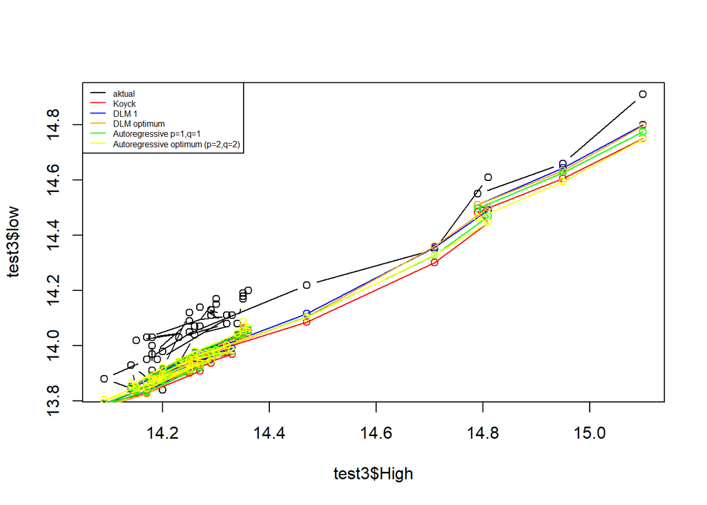

```r
par(mfrow=c(1,1))
plot(test3$High, test3$low, type="b", col="black")
points(test3$High, frc.koyck$forecasts,col="red")
lines(test3$High, frc.koyck$forecasts,col="red")
points(test3$High, frc.dl$forecasts,col="blue")
lines(test3$High, frc.dl$forecasts,col="blue")
points(test3$High, frc.dl.opt$forecasts,col="orange")
lines(test3$High, frc.dl.opt$forecasts,col="orange")
points(test3$High, frc.ardl$forecasts,col="green")
lines(test3$High, frc.ardl$forecasts,col="green")
points(test3$High, frc.ardl.opt$forecasts,col="yellow")
lines(test3$High, frc.ardl.opt$forecasts,col="yellow")
legend("topleft",c("aktual", "Koyck","DLM 1","DLM optimum","Autoregressive p=1,q=1", "Autoregressive optimum (p=2,q=2)"), lty=1, col=c("black","red","blue","orange","green","yellow"), cex=0.5)
```